# Sujet2

Mohamed Issa

16/05/2021

```r
rm(list=objects())
library(tidyverse)
library(latex2exp)
library(numDeriv)
library(coda)
library(ggmcmc)
```

# Simulation

### Question 1

Calculer la fonction quantile $F^{-1}(p|\alpha,\kappa)$ de la loi de Weibull, et en déduire un algorithme de simulation de cette loi basée sur l’inversion générique

En résolvant l’équation $F(t|\alpha,\kappa)=u$, on trouve: $t=(-\frac{\log(1-u))}{\alpha})^{\frac{1}{\kappa}}$

```r
my_pweibull <- function(x, kappa, alpha){
  return( 1 - exp( -alpha*(t^kappa)  ) )
}

my_qweibull <- function(u, kappa, alpha){
  return( (-log(1-u)/alpha )^(1/kappa) )
}

my_rweibull <- function(n, kappa, alpha){
  U = runif( n )
  X = my_qweibull( U, kappa, alpha )
  return( X )
}
```

### Question 2

Ecrire un programme R qui simule n observations de la loi de Weibull de paramètres alpha et kappa donnés, censurée au-dessus d’un niveau t0 donné (concrètement, on censure au-dessus de t0 en remplaçant chaque valeur simulée T par min(T, t0)). Le programme renvoie le vecteur de données simulées, ordonné de telle sorte que les p premières observations ne soient pas censurées, ainsi que le nombre p.

```r
sim_cens_weib=function(n, kappa, alpha, t0){
  res=numeric(n)
  X=my_rweibull(n,kappa, alpha)
  ind=which(X<t0)
  p=length(ind)
  if (p>=1){
   res[1:p]=X[ind]
  }
  if (p+1<=n){
    res[(p+1):n]=rep(t0,n-p)
  }
  return(list(sim=res,p=p))
}
```

# Calcul de la vraisemblance

### Question 3

Montrer que la log-vraisemblance $l(t1:n|α, κ, p)$, dans le modèle de Weibull dont les n − p dernières données sont censurées à droites, s’écrit :
$$l(t_{1:n}|α, κ, p)=p(\log(\alpha)+\log(\kappa))+(\kappa-1)\sum_{i=1}^p\log(t_i)-\alpha\sum_{i=1}^nt_i^\kappa$$

Pour les observations $t_i$ non censurées, la vraisemblance est égale au produit des valeurs de la densité de Weibull prises en t_i.
$$L(t_{i:1..p}|α, κ, p)=\prod_{i=1}^p \alpha\kappa t_i^{\kappa-1}exp(-\alpha t_i^\kappa)$$
Par suite la log vraisemblance s’écrit:
$$l((t_{i:1..p}|α, κ, p)=p\log(\alpha\kappa)+\sum_{i=1}^{p}(\kappa-1)\log(t_i)-\alpha t_i^\kappa$$

Pour les données censurées à droites, la log-vraisemblance s’écrit à l’aide de la fonction queue de la loi de Weibull.
$$l(t_{i:p+1..n}|α, κ, p)=\sum_{i=p+1}^{n}-\alpha t_i^\kappa$$
En calculant la somme des deux expressions on obtient:
$$l(t_{i:1..n}|α, κ, p)=p\log(\alpha\kappa)+\sum_{i=1}^{p}(\kappa-1)\log(t_i)-\alpha t_i^\kappa+\sum_{i=p+1}^{n}-\alpha t_i^\kappa \\
=p(\log(\alpha)+\log(\kappa))+(\kappa-1)\sum_{i=1}^p\log(t_i)-\alpha\sum_{i=1}^nt_i^\kappa$$

### Question 4

Donner l’expression exacte du gradient, et de la matrice hessienne de $l$.

Le gradient de $l$ est donné par:
$$\nabla l=
\begin{pmatrix}
\frac{\partial l}{\partial \alpha} \\
\frac{\partial l}{\partial \kappa}
\end{pmatrix} \\
=
\begin{pmatrix}
\frac{p}{\alpha}-\sum_{i=1}^nt_i^\kappa \\
\frac{p}{\kappa}+\sum_{i=1}^p\log(t_i)-\alpha\sum_{i=1}^n\log(t_i)t_i^\kappa
\end{pmatrix}$$

La matrice hessienne de $l$ est donné par:

$$\nabla^2 l=
\begin{pmatrix}
\frac{\partial^2 l}{\partial \alpha^2}& \frac{\partial^2 l}{\partial \kappa \partial \alpha}\\
\frac{\partial^2 l}{\partial \alpha \partial \kappa}&\frac{\partial^2 l}{\partial \kappa^2}
\end{pmatrix} \\
=
\begin{pmatrix}
\frac{-p}{\alpha^2} & 0 \\
-\sum_{i=1}^\kappa\log(t_i)t_i^\kappa & \frac{-p}{\kappa^2}-\alpha \sum_{i=1}^\kappa(\log(t_i))^2t_i^\kappa
\end{pmatrix}$$

# Approche fréquentiste

### Question 5

Montrer que l’estimateur du maximum de vraisemblance $\hat\alpha_{MLE}$ se déduit de l’estimateur du maximum de vraisemblance $\hat\kappa_{MLE}$ à l’aide d’une forumule qu’on explicitera, puis montrer que pour calculer ce dernier il faut résoudre un problème d’optimisation en 1D.

L’annulation du gradient de $l$ permet d’exprimer $\alpha$ en fonction de $\kappa$ sous la forme:

$$\alpha=\frac{p}{\sum_{i=1}^nt_i^\kappa}$$

Pour déterminer une estimation de $\kappa$, on maximise la log-vraisemblance profilée en injectant l’expression de $\alpha$ en fonction de $\kappa$. Ce qui amène à un problème d’optimisation en 1D.

$$l(\alpha=\frac{p}{\sum_{i=1}^nt_i^\kappa},\kappa)=p(\log(p)-\log(\sum_{i=1}^nt_i^\kappa)+\log(\kappa))+(\kappa-1)\sum_{i=1}^p\log(t_i)-p$$

### Question 6

À l’aide de la fonction optimize, écrire un programme R qui prend en entrée le vecteur t des durées de fonctionnement observées ; le nombre p de données non censurées, et qui calcule les estimateurs du maximum de vraisemblance de $(\alpha,\kappa)$.

```r
#func: opposée de la vraisemblance profilée
func=function(kappa,t,p){
  -p*(log(p)-log(sum(t**kappa))+log(kappa))-(kappa-1)*(sum(log(t)[1:p]))
}

MV=function(t,p){
  s=function(kappa) func(kappa,t=t,p=p)
  o=optimize(s,c(0.01,5))
  k=o$minimum
  a=p/sum(t**k)
  return(list(kappa=k,alpha=a))
}
```

### Question 7

7 Estimer $(\alpha,\kappa)$ par maximum de vraisemblance 100 fois, à partir de 100 jeux de données simulés à l’aide de la fonction écrite en première partie.

```r
n=1000       #taille de l'échantillon généré à chaque simulation
nsim=100     #nombre de simulations
alpha=5
kappa=2
t0=my_qweibull(0.6,kappa,alpha)

alpha_hat=numeric(nsim)
kappa_hat=numeric(nsim)
for (i in 1:nsim){
  l=sim_cens_weib(n,kappa,alpha,t0)
  res=MV(l$sim,l$p)
  alpha_hat[i]=res$alpha
  kappa_hat[i]=res$kappa
}


biais_alpha=mean(alpha_hat)-alpha
biais_kappa=mean(kappa_hat)-kappa

var_alpha=mean((alpha-mean(alpha_hat))**2)
var_kappa=mean((kappa-mean(kappa_hat))**2)

cv_alpha=sqrt(var_alpha)/mean(alpha_hat)
cv_kappa=sqrt(var_kappa)/mean(kappa_hat)
```

# Approche bayésienne

### Question 8

Montrer que, si la loi a priori sur $\alpha$ est la loi Gamma $\mathcal G(a, b)$, alors la loi a posteriori conditionnelle de $\alpha$ sachant$\kappa$, notée $\pi(\alpha|\kappa,t_{1:n},p)$, est encore une loi Gamma, dont on précisera les hyperparamètres.

$$\pi(\alpha) \sim \mathcal G(a, b)\propto\alpha^{a-1}e^{-b\alpha}$$

La loi à posteriori conditionnelle de $\alpha$ sachant $\kappa$ s’écrit:

$$\pi(\alpha|\kappa,t_{1:n},p) \propto L(t_{1:n}|\alpha,\kappa,p) \pi(\alpha) \\
\propto \alpha^{p+a-1}e^{-\alpha\sum_{i=1}^nt_i^k}\alpha^{a-1}e^{-b\alpha}\\
\propto \alpha^{p+a-1}e^{-(b+\sum_{i=1}^nt_i^\kappa)\alpha}$$
On en déduit que:
$$\pi(\alpha|\kappa,t_{1:n},p) \sim \mathcal G(p+a, b+\sum_{i=1}^nt_i^k)$$

Dans la suite, on prendra de même une loi a priori de type Gamma pour κ, de paramètres c et d, et on utilisera le choix “faiblement informatif” suivant : a = b = c = d = 10−3.

### Question 9

Montrer que la densité marginale a posteriori de κ est proportionnelle à :

$$\pi(\kappa|t_{1:n},p) \propto \pi(\kappa) \kappa^p \prod_{i=1}^pt_i^{\kappa-1}(b+\sum_{i=1}^nt_i^\kappa)^{-(a+n)}$$
———————————————————————-

On exprime $\pi(\alpha|\kappa,t_{1:n},p)$ en fonction de $\pi(\kappa|t_{1:n},p)$:

$$\pi(\alpha|\kappa,p,t_{1:n})=\frac{\pi(\alpha,\kappa|p,t_{1:n})}{\pi(\kappa|p,t_{1:n})}$$
Par suite:

$$\pi(\kappa|p,t_{1:n})=\frac{\pi(\alpha,\kappa|p,t_{1:n})}{\pi(\alpha|\kappa,p,t_{1:n})}$$
Or par indépendance des lois prior:
$$\pi(\alpha,\kappa|p,t_{1:n})=\mathcal L(t_{1:n}|\kappa,\alpha,p) \pi(\alpha)\pi(\kappa)$$
et on a:
$$\pi(\alpha|\kappa,p,t_{1:n})=\alpha^{p+a-1}e^{-(b+\sum_{i=1}^nt_i^\kappa)\alpha}(b+\sum_{i=1}^nt_i^\kappa)^{(a+n)}$$

En écrivant le rapport on déduit:
$$\pi(\kappa|p,t_{1:n})\propto\frac{\mathcal L(t_{1:n}|\kappa,\alpha,p) \pi(\alpha)\pi(\kappa)}{\alpha^{p+a-1}e^{-(b+\sum_{i=1}^nt_i^\kappa)\alpha}(b+\sum_{i=1}^nt_i^\kappa)^{-(a+n)}}\\
\propto\frac{\pi(\kappa)\kappa^p\prod_{i=1}^pt_i^{\kappa-1}e^{-\alpha\sum_{i=1}^nt_i^\kappa}}{\alpha^{p+a-1}e^{-\alpha(b+\sum_{i=1}^nt_i^\kappa)}(b+\sum_{i=1}^nt_i^\kappa)^{(a+n)}}\\
\propto \pi(\kappa)\kappa^p\prod_{i=1}^pt_i^{\kappa-1}(b+\sum_{i=1}^nt_i^\kappa)^{-(a+n)}$$
———————————————————————-

1. Montrer en supposant que $t_{max}=max_it_i>1$ les équivalents suivants:
   $$\pi(\kappa|t_{1:n},p) \underset{k\to0^+}{\sim} \pi(\kappa)\kappa^p
   \\
   \pi(\kappa|t_{1:n},p) \underset{k\to \infty}{\sim} \pi(\kappa)t_{max}^{\kappa(a+n)}$$
   En déduire quelles contraintes doit respecter la loi instrumentale g pour que le rapport $\pi(\kappa|t_{1:n},p)/g(\kappa)$ reste borné.

-quand $k\to0^+$, $\prod_{i=1}^pt_i^{\kappa-1}(b+\sum_{i=1}^nt_i^\kappa)^{-(a+n)} \to \prod_{i=1}^n\frac{1}{t_i}(b+n)^{-(a+n)}$ Par suite:
$$\pi(\kappa|t_{1:n},p) \underset{k\to0^+}{\sim} \pi(\kappa)\kappa^p$$
-quand $k\to\infty$, $(b+\sum_{i=1}^nt_i^\kappa)^{-(a+n)} \to t_{max}^{\kappa(a+n)}$ car $t_{max}=max_it_i>1$.

Par suite,
$$\pi(\kappa|t_{1:n,p}) \underset{k\to \infty}{\sim} \pi(\kappa)t_{max}^{-\kappa(a+n)}$$

Pour garantir la bornitude du rapport $\pi(\kappa|t_{1:n},p)/g(\kappa)$, il suffit d’imposer des conditions en observant le comportement aux bornes de l’ensemble de définition.

-quand $k\to0^+$:
$$\frac{\pi(\kappa|t_{1:n},p)}{g(\kappa)}\sim\frac{\kappa^n\kappa^{c-1}e^{-d\kappa}}{\kappa^{e-1}e^{-f\kappa}}
\sim \kappa^{n+c-e}$$
Pour garder un rapport borné, il suffit que $n+c-e \geq 0$ c-à-d $e \leq n+c$.

-quand $k\to\infty$:

$$\frac{\pi(\kappa|t_{1:n},p)}{g(\kappa)}\sim\frac{\kappa^{c-1}e^{-d\kappa}t_{max}^{-\kappa(a+n)}}{\kappa^{e-1}e^{-f\kappa}}\\
\sim e^{(c-e)\log(\kappa)-\kappa[d-f+(a+n)\log(t_{max})]}$$

*si $d-f+(a+n)\log(t_{max}) > 0$, alors le rapport est borné.

*si $d-f+(a+n)\log(t_{max}) = 0$, alors le rapport est borné à condition que $c-e\leq0$.

*si $d-f+(a+n)\log(t_{max}) < 0$, alort le rapport n’est pas borné.

Par suite, pour garder la bornitude au voisinage de $\infty$ il faut et il suffit que e et f soient dans l’ensemble:

$$\{d+(a+n)\log(t_{max}) > f\} \cup {\{\{d+(a+n)\log(t_{max}) = f\}\cap\{c\leq e\}}\}$$

2. Calculer $\hat{\kappa}_{MAP}=arg max_\kappa$ $\pi(\kappa|t_{1:n},p)$ à l’aide de la fonction optimize et l’approximation de Laplace de la variance a posteriori de $\kappa$. ———————————————————————-

```r
setwd("C:/Users/issa/Desktop/TA/2ata/STA211/proj")
d=read.csv("donnees_Weibull_censure.csv")
t=d$x
n=length(t)
p=6
```

```r
a=b=c=d=10**(-3)

neg_log=function(kappa){
  - dgamma(kappa, c, d, log=TRUE)- p * log(kappa) + (a+n) * log(b+sum(t**kappa))  - (kappa-1) * sum(log(t)[1:p])
}



kappa_MAP = optimize(neg_log, interval=c(0.1, 10) )$minimum


hat_v_beta = 1/hessian(neg_log, kappa_MAP)

#on peut calculer l'estimateur MAP de alpha:
alpha_MAP=p/(sum(t**kappa_MAP))
```

3. Choisir pour loi instrumentale g la loi Gamma d’espérance égale à $\hat{\kappa}_{MAP}$ et de variance égale à $\sigma_{\kappa MAP}^2$, en vérifiant qu’elle respecte les conditions en 1 pour que le rapport $\frac{\pi(\kappa|t_{1:n},p)}{g(\kappa)}$ soit borné.

si $g \sim \mathcal G(e,f)$ de moyenne $\hat{\kappa}_{MAP$ et de variance $\hat\sigma_{\kappa MAP}^2$ alors:
$$e=(\frac{\hat{\kappa}_{MAP}}{\hat\sigma_{\kappa MAP}})^2\\
f=\frac{\hat{\kappa}_{MAP}}{\hat\sigma_{\kappa MAP}^2}$$

```r
e=(kappa_MAP**2)/hat_v_beta
f=kappa_MAP/hat_v_beta

#vérification des conditions:

if (( e <= n + c ) & ((f < ((a+n)*log(max(t))+d)) | ((f == ((a+n)*log(max(t))+d))&(c<=e)))){
 print("loi instrumentale conforme")
}else{
 print("loi instrumentale non conforme")
}
```

```
## [1] "loi instrumentale conforme"
```

4. Toujours en utilisant la fonction optimize, calculer le sup du quotient $M=sup_\kappa$ $\frac{\pi(\kappa|t_{1:n},p)}{g(\kappa)}$.

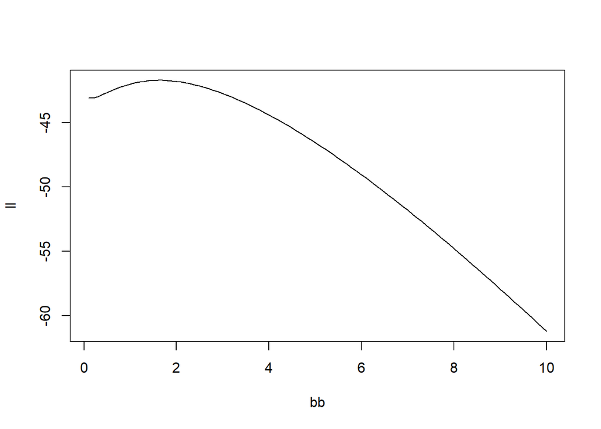

```r
quot_log=function(kappa){
  -neg_log(kappa)-dgamma(kappa,e,f,log=TRUE)
}


bb = seq(0.1, 10, length.out=100)
ll = c()
for (b in bb){ll=c(ll, quot_log(b))}

plot(bb, ll, type='l')
```

```r
o=optimize(quot_log,interval=c(0.1,10),maximum=T)
logM=o$objective
```

10. Ecrire un programme R qui génère par une méthode d’acceptation-rejet un échantillon $\kappa_1,..,\kappa_G$ de taille $G=10000$ selon la densité marginale a posteriori $\pi(\kappa|t_{1:n},p)$. Puis, pour $g=1,..,G$, simuler $\alpha_g$ dans la loi conditionnelle a posteriori $\pi(\alpha|t_{1:n},p)$ pour $\kappa=\kappa_g$. Représenter les densités a priori et a posteriori pour chaque paramètre, ainsi que le graphe de corrélation a posteriori du couple $(\kappa,\alpha^{-1/\kappa})$.

```r
rf_kappa_post <- function(nsimu){
 n_accept <- 0
 n_gen <- 0
 Y = c()
while( n_accept < nsimu){
 X <- rgamma(1, e, f)
 n_gen <- n_gen + 1
 U <- runif(1)
 accept <- log(U) + logM + dgamma(X, e,f,log=TRUE) <= -neg_log( X ) # tirages accepts
if (accept){
 n_accept <- n_accept + 1
 Y = c(Y, X)
 }
 }
return( list( X=Y, accept_rate = nsimu / n_gen ) )
}
```

```r
nsimu = 10000
kappa_post = rf_kappa_post(nsimu)
alpha_post = c()
for (k in kappa_post$X){
 a = rgamma(1, n+a, b+sum(t^k) )
 alpha_post = c(alpha_post, a)
}
```

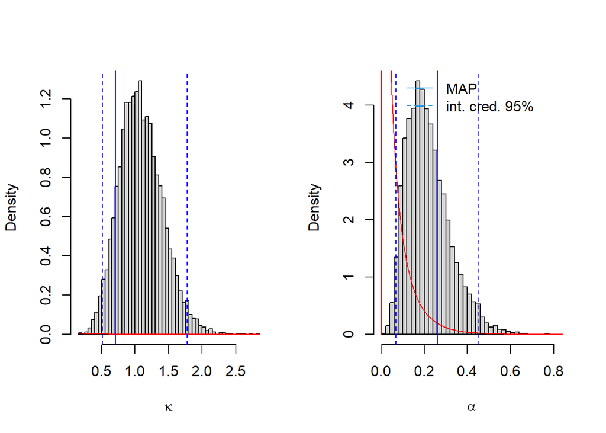

```r
par(mfrow=c(1,2))
hist(kappa_post$X, breaks="Scott", probability=TRUE, main="", xlab=TeX('$\\kappa$'))
curve(dgamma(x,c,d), col='red', add=TRUE)
abline(v=kappa_MAP, col='blue', lty=1)
abline(v=quantile(kappa_post$X, .025), col='blue', lty=2)
abline(v=quantile(kappa_post$X, .975), col='blue', lty=2)

hist(alpha_post, breaks="Scott", probability=TRUE, main="", xlab=TeX('$\\alpha$'))
curve(dgamma(x,a,b), col='red', add=TRUE)
abline(v=alpha_MAP, col='blue', lty=1)
abline(v=quantile(alpha_post, .025), col='blue', lty=2)
abline(v=quantile(alpha_post, .975), col='blue', lty=2)
legend( "top", legend=c(TeX("MAP"), "int. cred. 95%"),bty='n', pch=c('_','_'), lty=c(1,2),col=c(4,4))
```

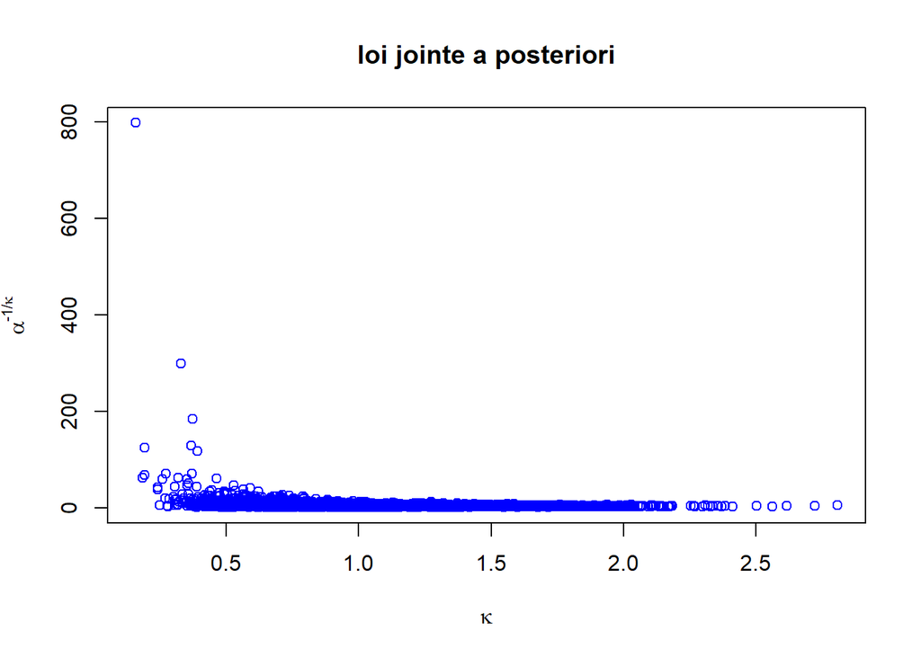

```r
plot(kappa_post$X,alpha_post**(-1/kappa_post$X), col='blue', main="loi jointe a posteriori", xlab=TeX("$\\kappa$"), ylab=TeX("$\\alpha^{-1/\\kappa}$"))
```

11. Implémenter un algorithme MCMC sous la forme d’une fonction R nommée MCMC qui va permettre d’échantillonner dans la loi jointe a posteriori du couple $(\alpha,\kappa)$ sachant les données $t_{1:n}$ et $p$.

```r
MCMC=function(G,alpha0,kappa0,delta){

  n_accept=1    #intitialisation du nombre d'échantillons accéptés pour kappa
  chain=matrix(nrow=G,ncol=2,byrow=T,dimnames=list(NULL,c("alpha","kappa")))

  alpha_curr=alpha0
  kappa_curr=kappa0

  chain[1,1]=alpha_curr
  chain[1,2]=kappa_curr

  for (i in 2:G){
  #échantillonneur de Gibbs pour alpha:
  alpha_cand=rgamma(1,a+p,b+sum(t**kappa_curr))

  #échantillonneur de MH pour kappa:
  accept_k=1
  kappa_cand=rnorm(1,kappa_curr,delta)
  if (kappa_cand>0){
    logr=(-neg_log(kappa_cand)+neg_log(kappa_curr))
    u=runif(1,0,1)
    if (log(u)>min(0,logr)){
      kappa_cand=kappa_curr
      accept_k=0
    }
  }
  if (kappa_cand<0){  #on n'accepte pas
    kappa_cand=kappa_curr
    accept_k=0
  }
  n_accept=n_accept+accept_k
  chain[i,1]=alpha_cand
  chain[i,2]=kappa_cand
  kappa_curr=kappa_cand
  }

  return(list(chain=chain,taux_accept_k=n_accept/G))
}
```

12. Choix du paramètre de saut $\delta$:Utiliser la fonction MCMC précédemment implémentée pour calculer puis tracer l’évolution du taux d’acceptation associé à la mise à jour de κ en fonction de différentes valeurs du paramètre δ. Pour chaque valeur de δ, on pourra faire tourner l’algorithme MCMC pendant G = 10 000 itérations et qu’avec une seule chaîne de Markov pour cette étape de calibration. Quelle valeur de δ vous semble la meilleure (rappel : viser un taux d’acceptation d’environ 40%) ? Vous conserverez cette valeur pour la suite.

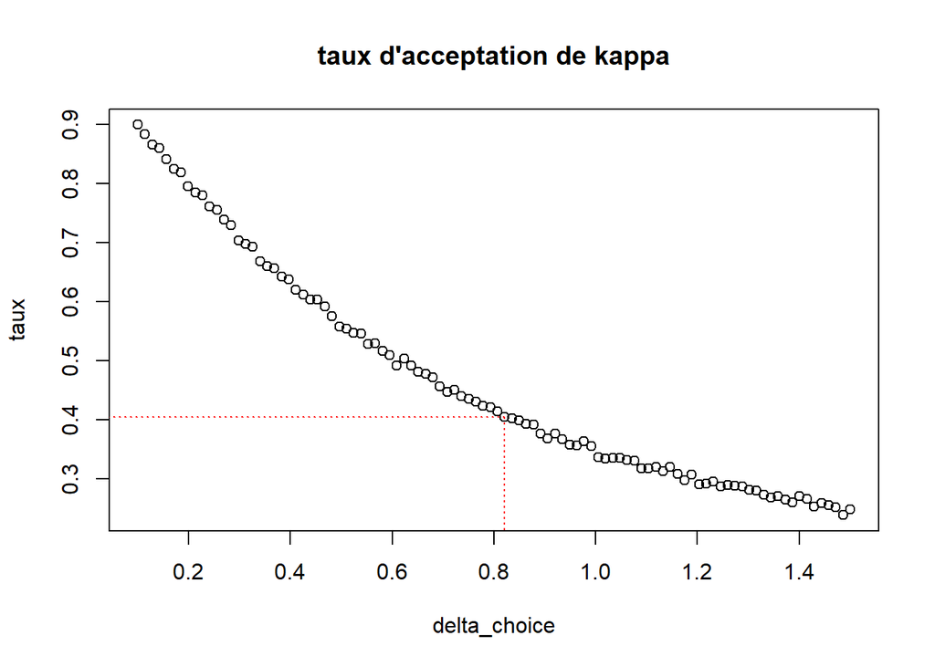

```r
G=10000

return_accept_k=function(G,alpha0,kappa0,delta){
  return(MCMC(G,alpha0,kappa0,delta)$taux_accept_k)
}

delta_choice=seq(0.1,1.5,length.out=100)
taux=lapply(delta_choice,return_accept_k,G=G,alpha0=2,kappa0=0.1)
M=as.matrix(taux,nrow=1)
ind=which((M>=0.39)&(M<0.41))[1]
plot(delta_choice,M,main="taux d'acceptation de kappa",ylab="taux")
segments(x0=c(delta_choice[ind],delta_choice[ind]),y0=c(M[[ind]],M[[ind]]),x1=c(delta_choice[ind],0),y1=c(0,M[[ind]]),col="red",lty=3)
```

```r
print(delta_choice[ind]) #valeur de delta correspondant à un taux de 40%
```

```
## [1] 0.8212121
```

13. Lancer à présent 3 chaînes de Markov à partir de positions initiales différentes en fixant δ à la valeur précedemment choisie afin de générer un échantillon $((\alpha^{(1)},\kappa^{(1)}),...,(\alpha^{(G)},\kappa^{(G)}))$ de taille $G=10000$. Faites un examen visuel des chaînes de Markov obtenues et calculer la statistique de Gelman-Rubin. Identifiez-vous un problème de convergence de l’algorithme MCMC implémenté vers sa loi stationnaire ? Si oui, comment proposez-vous d’y remédier ? Combien d’itérations X vous semblent a minima nécessaires pour espérer avoir atteint l’état stationnaire ?

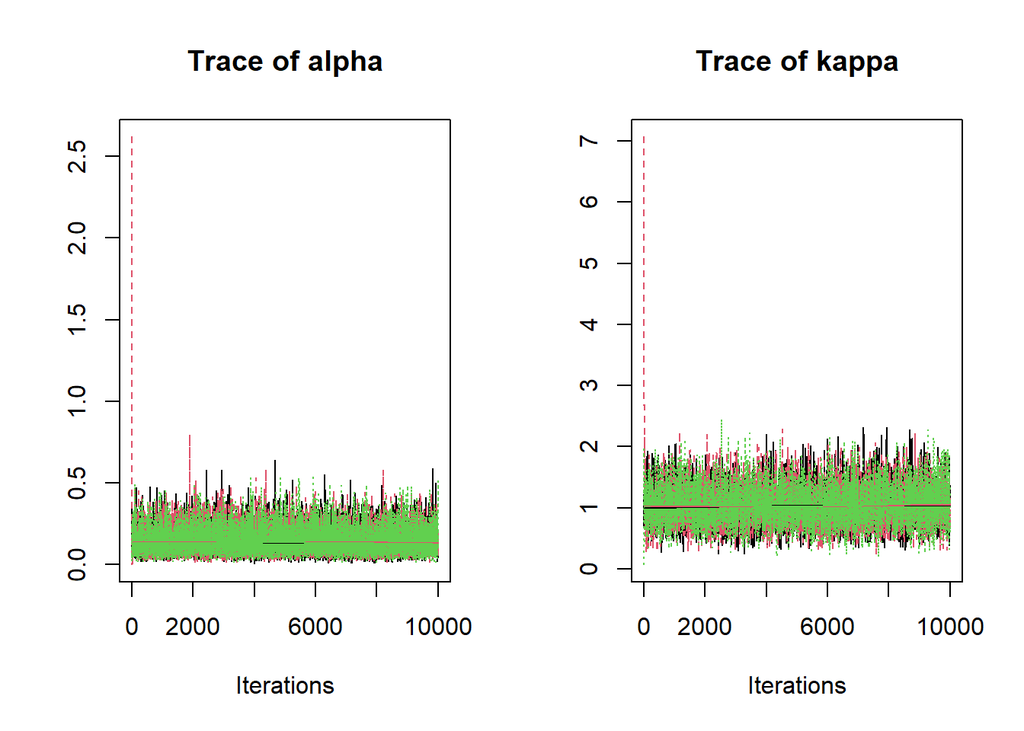

```r
delta=delta_choice[ind]

kappa1=kappa_MAP
kappa2=kappa_MAP*10
kappa3=kappa_MAP/10

alpha1=alpha_MAP
alpha2=alpha_MAP*10
alpha3=alpha_MAP/10


chain1=MCMC(G,alpha1,kappa1,delta)
chain2=MCMC(G,alpha2,kappa2,delta)
chain3=MCMC(G,alpha3,kappa3,delta)

mcmcchains=mcmc.list(mcmc(chain1$chain),mcmc(chain2$chain),mcmc(chain3$chain))

plot(mcmcchains, density=FALSE)
```

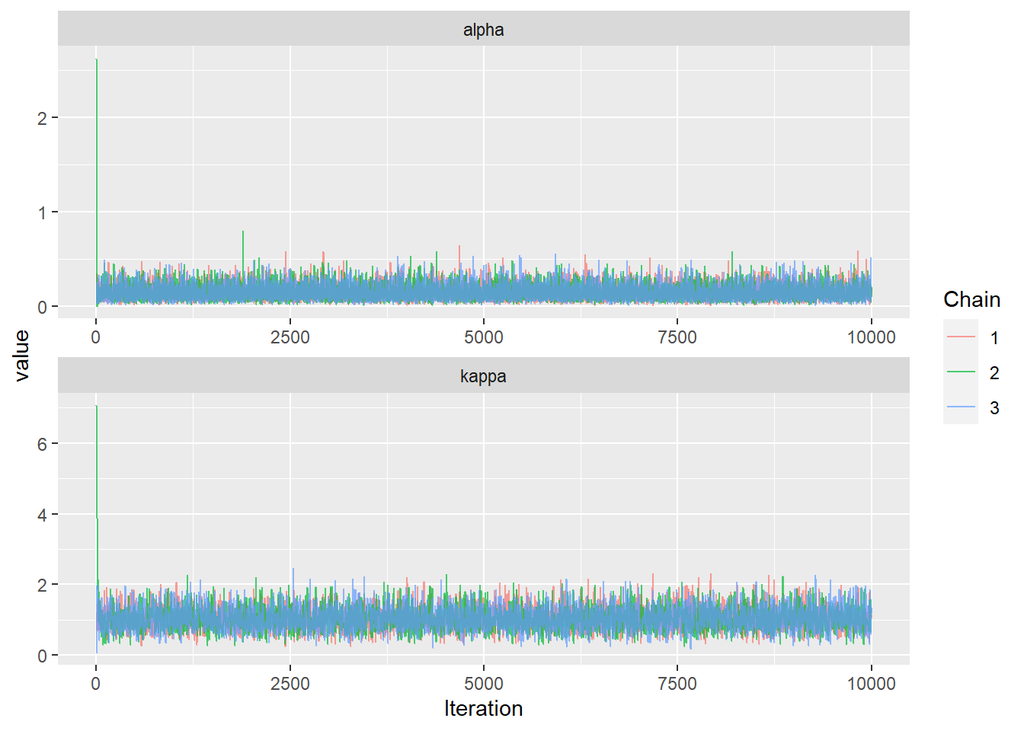

```r
model.samples.gg <- ggs(mcmcchains)
ggs_traceplot(model.samples.gg)
```

On observe qu’il n’y a pas à priori un problème de convergence. D’après la représentation des traces des paramètres $\alpha$ et $\kappa$ les chaînes de Markov générées visitent ,après un certain nombre d’itérations, la même zone correspondante à la loi stationnaire de chaque chaîne.

-Calcul du critère de Gelman_Rubin sur l’ensemble des itérations des trois chaînes de Markov calculées.

```r
gelman.diag(mcmcchains)
```

```
## Potential scale reduction factors:
##
##       Point est. Upper C.I.
## alpha          1          1
## kappa          1          1
##
## Multivariate psrf
##
## 1
```

-Représentation graphique du critère au cours des itérations.

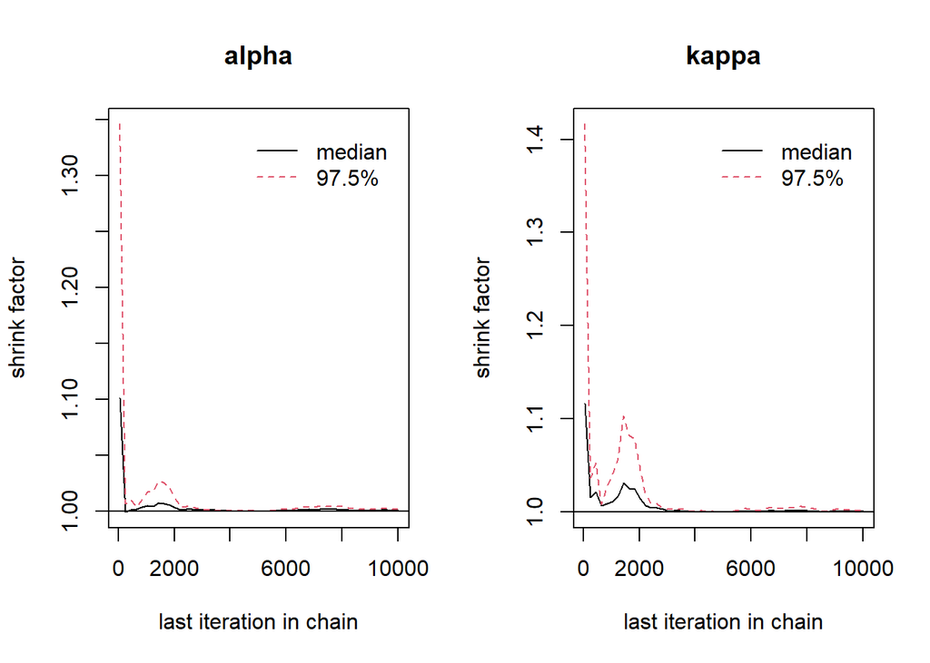

```r
gelman.plot(mcmcchains)
```

On remarque qu’il n’y a pas un problème de convergence. D’après la représentation graphique du critère au cours des itérations, on voit que les courbes se stabilisent à partir de l’itération 3000. Les 3000 premières itérations correspondent au temps de chauffe $X$.

14)Supprimer les $X$ premières itérations correspondant à votre temps-de chauffe “estimé” de l’algorithme afin de constituer votre échantillon a posteriori. Calculer la taille d’échantillon effective (ESS) de l’échantillon a posteriori constitué. Qu’en pensez-vous ? Si l’ESS vous semble trop petit, refaites tourner l’algorithme en augmentant le nombre d’itérations G jusqu’à obtenir un ESS “satisfaisant” pour bien estimer $α$ et $κ$.

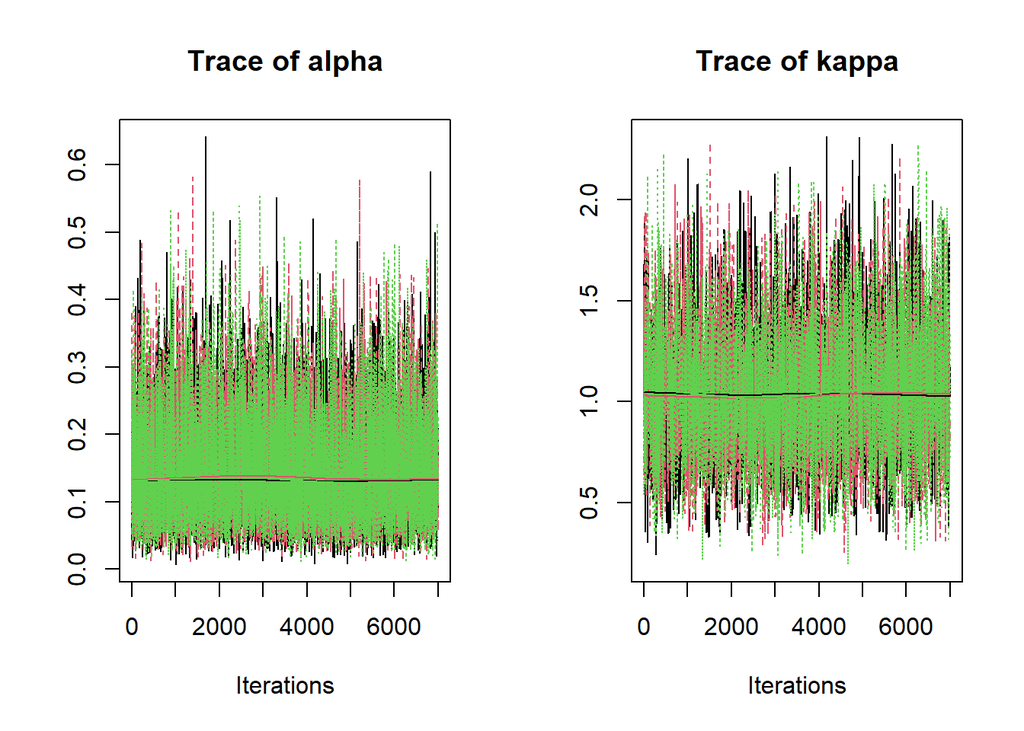

```r
#Temps de chauffe estimé
nburnin = 3000

#Visualisation des chaînes de Markov après avoir supprimé les itérations de temps de chauffe supposé
mcmcchains <- mcmc.list(list(mcmc(chain1$chain[nburnin:G,]),mcmc(chain2$chain[nburnin:G,]),mcmc(chain3$chain[nburnin:G,])))
plot(mcmcchains, density=FALSE)
```

On calcule le taille de l’échantillon à posteriori après avoir enlevé les itérations du temps de chauffe:

```r
taille=(G-nburnin)*3
print(taille)
```

```
## [1] 21000
```

```r
Ess=effectiveSize(mcmcchains)
```

```r
Respost<- summary(mcmcchains)
Respost$statistics[,4]< 0.05*Respost$statistics[,2]
```

```
## alpha kappa
##  TRUE  TRUE
```

On remarque que la taille de l’échantillon effective est suffisante pour bien estimer $\alpha$ et $\kappa$. En effet, l’erreur de Monte-Carlo estimée (Time-series SE) est inférieure à $5\%$ de l’écart-type a posetriori empirique.

15. Représenter les densités a priori et a posteriori pour chaque paramètre, ainsi que le graphe de corrélation a posteriori du couple $(κ, α−1/κ)$. Comparer les résultats issus des deux algorithmes d’inférence bayésienne. Lequel préférez-vous?

```r
Respost
```

```
##
## Iterations = 1:7001
## Thinning interval = 1
## Number of chains = 3
## Sample size per chain = 7001
##
## 1. Empirical mean and standard deviation for each variable,
##    plus standard error of the mean:
##
##         Mean      SD  Naive SE Time-series SE
## alpha 0.1424 0.07371 0.0005086      0.0007529
## kappa 1.0507 0.31185 0.0021518      0.0045247
##
## 2. Quantiles for each variable:
##
##          2.5%     25%    50%    75%  97.5%
## alpha 0.03961 0.08826 0.1286 0.1817 0.3212
## kappa 0.50138 0.83326 1.0304 1.2469 1.7317
```

-Les densité à prioiri:

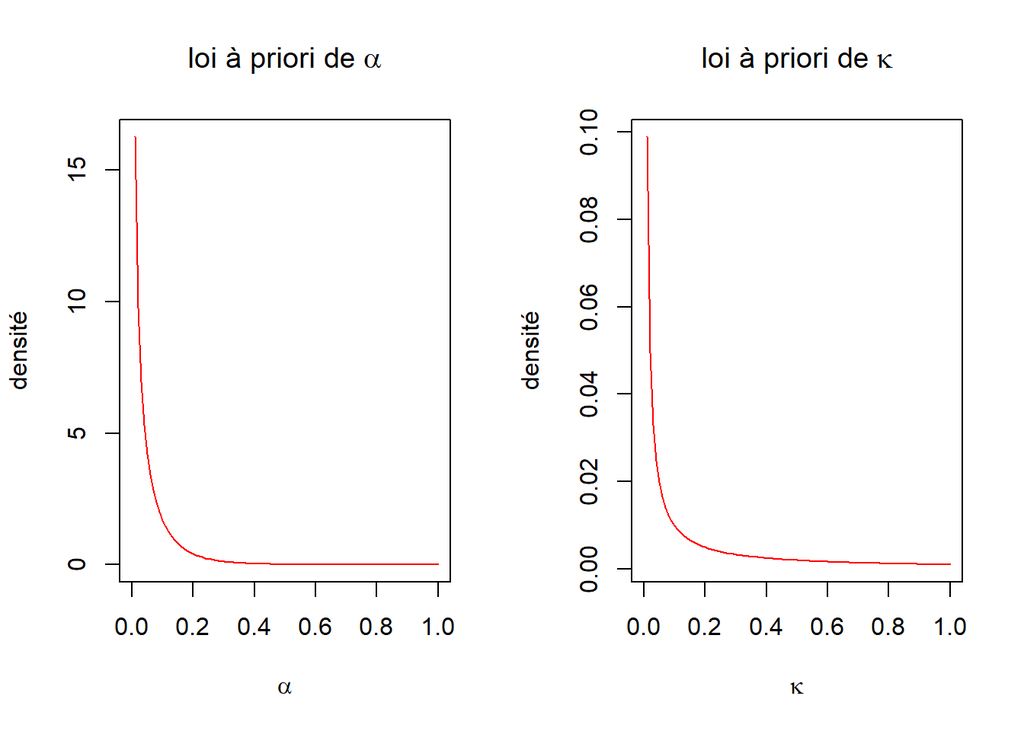

```r
par(mfrow=c(1,2))
curve(dgamma(x,a,b), col='red',main=TeX('loi à priori de $\\alpha$'),xlab=TeX('$\\alpha$'),ylab='densité')
curve(dgamma(x,c,d), col='red',main=TeX('loi à priori de $\\kappa$'),xlab=TeX('$\\kappa$'),ylab='densité')
```

-Les densité à posteriori:

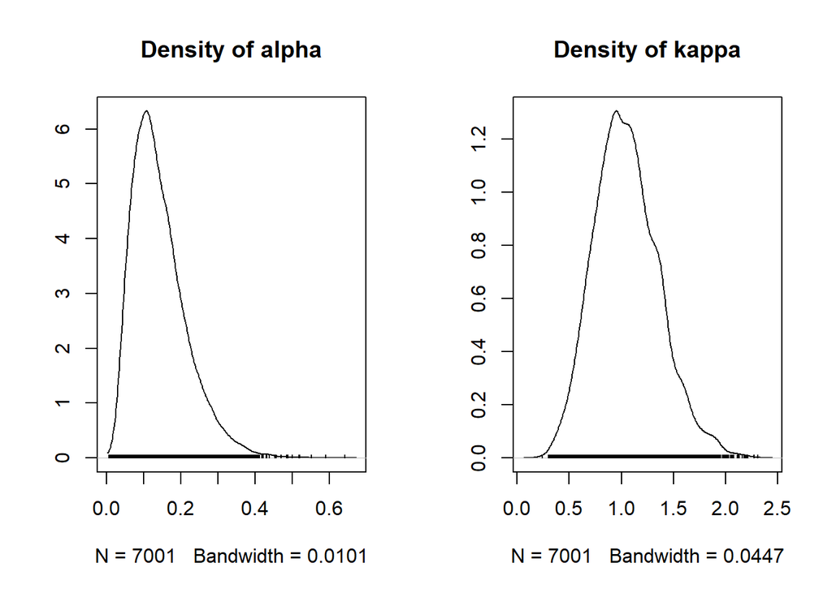

```r
plot(mcmcchains,density=T,trace=F)
```

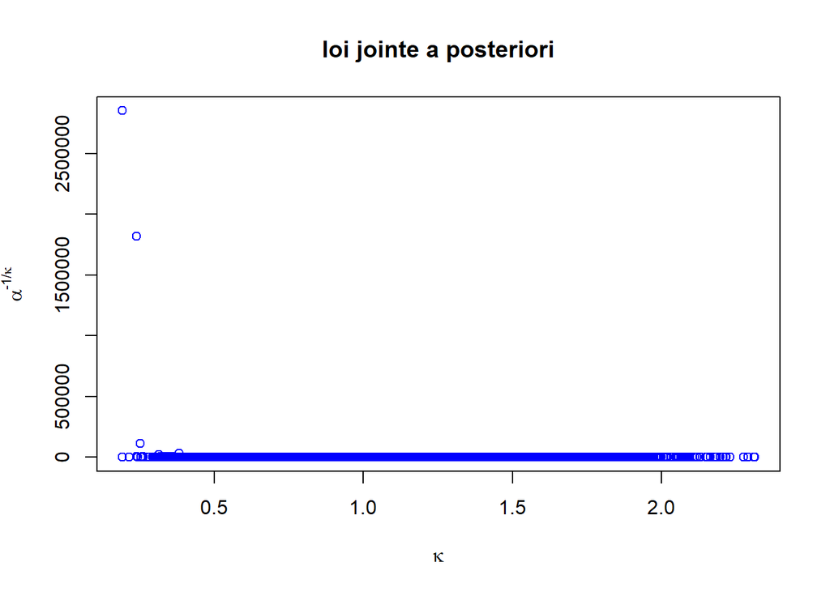

```r
alpha_mcmc=c(mcmc(chain1$chain[nburnin:G,1]),mcmc(chain2$chain[nburnin:G,1]),mcmc(chain3$chain[nburnin:G,1]))

kappa_mcmc=c(mcmc(chain1$chain[nburnin:G,2]),mcmc(chain2$chain[nburnin:G,2]),mcmc(chain3$chain[nburnin:G,2]))

plot(kappa_mcmc,alpha_mcmc**(-1/kappa_mcmc), col='blue', main="loi jointe a posteriori", xlab=TeX("$\\kappa$"), ylab=TeX("$\\alpha^{-1/\\kappa}$"))
```